# Project-2

### Logic and Classical Planning

[figure not shown]

Pacman and ghosts

Logical Pacman,  
Food is good AND ghosts are bad,  
Spock would be so proud

# Introduction

In this project, you will use/write simple Python functions that generate logical sentences describing Pacman physics, aka pacphysics. Then you will use a SAT solver, pycosat, to solve the logical inference tasks associated with planning (generating action sequences to reach goal locations and eat all the dots), localization (finding oneself in a map, given a local sensor model), mapping (building the map from scratch), and SLAM (simultaneous localization and mapping).

As in previous programming assignments, this assignment includes an autograder for you to grade your answers on your machine. This can be run with the command:

```bash
python autograder.py
```

The code for this project contains the following files, available as a zip archive on Teams in the homework page.

**Files you’ll edit:**

```bash
logicPlan.py
```

Where you will put your code for the various logical agents.

**Files you might want to look at:**

```bash
logic.py
```

Propsitional logic code originally from [aima-python](https://code.google.com/p/aima-python/) with modifications for our project. There are several useful utility functions for working with logic in here.

```bash
logicAgents.py
```

The file that defines in logical planning form the two specific problems that Pacman will encounter in this project.

```bash
pycosat_test.py
```

Quick test main function that checks that the pycosat module is installed correctly.

```bash
game.py
```

```bash
test_cases/
```

Directory containing the test cases for each question.

**Supporting files you can ignore:**

```bash
pacman.py
```

The main file that runs Pacman games.

```bash
logic_util.py
```

Utility functions for `logic.py`.

```bash
util.py
```

Utility functions primarily for other projects.

```bash
logic_planTestClasses.py
```

Project specific autograding test classes.

```bash
graphicsDisplay.py
```

Graphics for Pacman.

```bash
graphicsUtils.py
```

Support for Pacman graphics.

```bash
textDisplay.py
```

ASCII graphics for Pacman.

```bash
ghostAgents.py
```

Agents to control ghosts.

```bash
keyboardAgents.py
```

Keyboard interfaces to control Pacman.

```bash
layout.py
```

Code for reading layout files and storing their contents.

```bash
autograder.py
```

Project autograder.

```bash
testParser.py
```

Parses autograder test and solution files.

```bash
testClasses.py
```

General autograding test classes.

**Files to Edit and Submit**: You will upload a .zip on Teams containing all the files you were given (with your code where neeeded).

**Evaluation**: Your code will be autograded for technical correctness. Please do not change the names of any provided functions or classes within the code, or you will wreak havoc on the autograder. The autograder score will be the majority of your homework grade, but, if necessary, we will review and grade assignments individually to ensure that you receive due credit for your work.

**Getting Help**: You are not alone! If you find yourself stuck on something, contact us!

# The Expr Class

In the first part of this project, you will be working with the `Expr` class defined in `logic.py` to build propositional logic sentences. An `Expr` object is implemented as a tree with logical operators ($\land, \lor, \neg, \rightarrow, \leftrightarrow$) at each node and with literals ($A,B,C$) at the leaves. Here is an example sentence and its representation:

$$(A \land B) \leftrightarrow (\neg C \lor D)$$

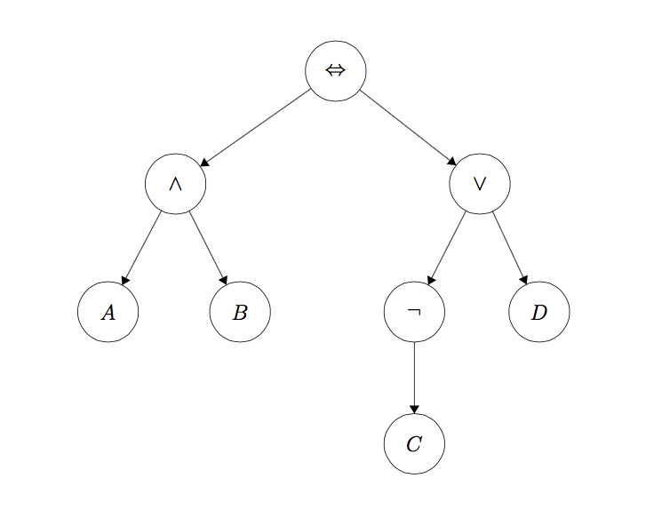

Logic tree of first expression

To instantiate a symbol named `'A'`, call the constructor like this:

```
A = Expr('A')
```

The `Expr` class allows you to use Python operators to build up these expressions. The following are the available Python operators and their meanings:

- `~A`: $\neg A$
- `A & B`: $A \land B$
- `A | B`: $A \lor B$
- `A >> B`: $A \rightarrow B$
- `A % B`: $A \leftrightarrow B$

So to build the expression $A \land B$, you would type this:

[output not shown]

(Note that `A` to the left of the assignment operator in that example is just a Python variable name, i.e. `symbol1 = Expr('A')` would have worked just as well.)

## A note on conjoin and disjoin

One last important thing to note is that you must use `conjoin` and `disjoin` operators wherever possible. `conjoin` creates a chained `&` (logical AND) expression, and `disjoin` creates a chained `|` (logical OR) expression. Let’s say you wanted to check whether conditions A, B, C, D, and E are all true. The naive way to achieve this is writing `condition = A & B & C & D & E`, but this actually translates to `((((A & B) & C) & D) & E)`, which creates a very nested logic tree (see (1) in diagram below) and becomes a nightmare to debug. Instead, `conjoin` makes a flat tree (see (2) in diagram below).

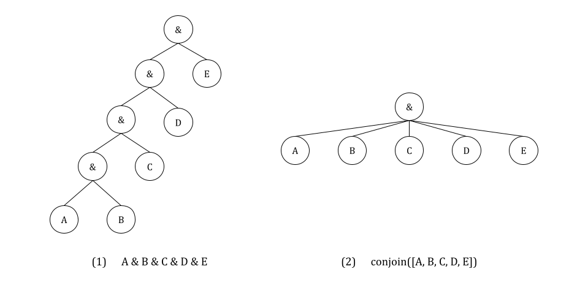

Flat logic tree

# Prop Symbol Names (Important!)

For the rest of the project, please use the following variable naming conventions:

### Rules

- When we introduce variables, they must start with an upper-case character (including `Expr`).
- Only these characters should appear in variable names: `A-Z`, `a-z`, `0-9`, `_`, `^`, `[`, `]`.
- Logical connective characters (`&`, `|`) must not appear in variable names. So, `Expr('A & B')` is illegal because it attempts to create a single constant symbol named `'A & B'`. We would use `Expr('A') & Expr('B')` to make a logical expression.

### Pacphysics symbols

- `PropSymbolExpr(pacman_str, x, y, time=t)`: whether or not Pacman is at $(x, y)$ at time $t$, writes `P[x,y]_t`.
- `PropSymbolExpr(wall_str, x, y)`: whether or not a wall is at $(x, y)$, writes `WALL[x,y]`.
- `PropSymbolExpr(action, time=t)`: whether or not pacman takes action action at time $t$, where action is an element of `DIRECTIONS`, writes i.e. `North_t`.
- In general, `PropSymbolExpr(str, a1, a2, a3, a4, time=a5)` creates the expression `str[a1,a2,a3,a4]_a5` where `str` is just a string.

There is additional, more detailed documentation for the `Expr` class in `logic.py`.

# SAT Solver Setup

A SAT (satisfiability) solver takes a logic expression which encodes the rules of the world and returns a model (true and false assignments to logic symbols) that satisfies that expression if such a model exists. To efficiently find a possible model from an expression, we take advantage of the [pycosat](https://pypi.org/project/pycosat/) module, which is a Python wrapper around the [picoSAT](http://fmv.jku.at/picosat/) library.

Unfortunately, this requires installing this module/library on each machine. In the command line, run `pip install pycosat`, or `pip3 install pycosat` on some setups, or `conda install pycosat` for `conda`.

On Windows, if you are getting an error message saying `error: Microsoft Visual C++ 14.0 or greater is required. Get it with "Microsoft Build Tools": ...`, you will have to install a C/C++ compiler following that link; or, use `conda install pycosat`, for which you will need to have Anaconda installed (recommend uninstalling current Python before installing a new one) and run this from the Anaconda prompt.

Testing `pycosat` installation:

After unzipping the project code and changing to the project code directory, run:

```
python pycosat_test.py
```

This should output:

```
[1, -2, -3, -4, 5]
```

Please let us know if you have issues with this setup. This is critical to completing the project, and we don’t want you to spend your time fighting with this installation process.

# Q1 (2 points): Logic Warm-up

This question will give you practice working with the `Expr` data type used in the project to represent propositional logic sentences. You will implement the following functions in `logicPlan.py`:

- `sentence1()`: Create one `Expr` instance that represents the proposition that the following three sentences are true. Do not do any logical simplification, just put them in a list in this order, and return the list conjoined. Each element of your list should correspond to each of the three sentences.

$$A \lor B$$
$$\neg A \leftrightarrow (\neg B \lor C)$$
$$\neg A \lor \neg B \lor C$$

- `sentence2()`: Create one `Expr` instance that represents the proposition that the following four sentences are true. Again, do not do any logical simplification, just put them in a list in this order, and return the list conjoined.

$$C \leftrightarrow (B \lor D)$$
$$A \rightarrow (\neg B \land \neg
D)$$
$$\neg (B \land \neg C)
\rightarrow A$$
$$\neg D \rightarrow
C$$

- `sentence3()`: Using the `PropSymbolExpr` constructor, create the symbols `'PacmanAlive_0'`, `'PacmanAlive_1'`, `'PacmanBorn_0'`, and `'PacmanKilled_0'` (*hint*: recall that `PropSymbolExpr(str, a1, a2, a3, a4, time=a5)` creates the expression `str[a1,a2,a3,a4]_a5` where `str` is a string; you should make some strings for this problem to match these exactly). Then, create one `Expr` instance which encodes the following three English sentences as propositional logic in this order without any simplification:
  1. Pacman is alive at time 1 if and only if he was alive at time 0 and he was not killed at time 0 or he was not alive at time 0 and he was born at time 0.
  2. At time 0, Pacman cannot both be alive and be born.
  3. Pacman is born at time 0.
- `findModelUnderstandingCheck()`:
  1. Look at how the `findModel(sentence)` method works: it uses `to_cnf` to convert the input sentence into Conjunctive Normal Form (the form required by the SAT solver), and passes it to the SAT solver to find a satisfying assignment to the symbols in `sentence`, i.e., a model. A model is a dictionary of the symbols in your expression and a corresponding assignment of `True` or `False`. Test your `sentence1()`, `sentence2()`, and `sentence3()` with findModel by opening an interactive session in Python and running `from logicPlan import *` and `findModel(sentence1())` and similar queries for the other two. Do they match what you were expecting?
  2. Based on the above, fill in `findModelUnderstandingCheck` so that it returns what `findModel(Expr('a'))` would return if lower case variables were allowed. You should not use `findModel` or `Expr` beyond what’s already given; simply directly recreate the output.
- `entails(premise, conclusion)`: Return `True` if and only if the `premise` entails the `conclusion`. *Hint*: `findModel` is helpful here; think about what must be unsatisfiable in order for the entails to be `True`, and what it means for something to be unstatisfiable.
- `plTrueInverse(assignments, inverse_statement)`: Returns `True` if and only if the (not `inverse_statement`) is `True` given `assignments`.

Before you continue, try instantiating a small sentence, e.g.

$$A \land B \rightarrow C$$
, and call `to_cnf` on it. Inspect the output and make sure you understand it (refer to AIMA section 7.5.2 for details on the algorithm `to_cnf` implements).

To test and debug your code run:

```bash
    python autograder.py -q q1
```

# Q2 (2 points): Logic Workout

Implement the following three functions in `logicPlan.py` (remembering to use `conjoin` and `disjoin` whenever possible):

- `atLeastOne(literals)`: Return a single expression (`Expr`) in CNF that is true only if at least one expression in the input list is true. Each input expression will be a literal.
- `atMostOne(literals)`: Return a single expression (`Expr`) in CNF that is true only if at most one expression in the input list is true. Each input expression will be a literal. *Hint*: Use `itertools.combinations`. If you have $n$ literals, and at most one is true, your resulting CNF expression should be a conjunction of $n \choose 2$ clauses.
- `exactlyOne(literals)`: Use `atLeastOne` and `atMostOne` to return a single expression (`Expr`) in CNF that is true only if exactly one expression in the input list is true. Each input expression will be a literal.

Each of these methods takes a list of `Expr` literals and returns a single `Expr` expression that represents the appropriate logical relationship between the expressions in the input list. An additional requirement is that the returned `Expr` must be in CNF (conjunctive normal form). **You may NOT use the `to_cnf`** function in your method implementations (or any of the helper functions `logic.eliminate_implications`, `logic.move_not_inwards`, and `logic.distribute_and_over_or`).

Don’t run `to_cnf` on your knowledge base when implementing your planning agents in later questions. This is because `to_cnf` makes your logical expression much longer sometimes, so you want to minimize this effect; `findModel` does this as needed. In later questions, reuse your implementations for `atLeastOne(.)`, `atMostOne(.)`, and `exactlyOne(.)` instead of re-engineering these functions from scratch. This avoids accidentally making unreasonably slow non-CNF-based implementations.

You may utilize the `logic.pl_true` function to test the output of your expressions. `pl_true` takes an expression and a model and returns `True` if and only if the expression is true given the model.

To test and debug your code run:

```bash
    python autograder.py -q q2
```

# Q3 (4 points): Pacphysics and Satisfiability

In this question, you will implement the basic pacphysics logical expressions, as well as learn how to prove where pacman is and isn’t by building an appropriate knowledge base (KB) of logical expressions.

Implement the following functions in `logicPlan.py`:

- `pacmanSuccessorAxiomSingle` – this generates an expression defining the sufficient and necessary conditions for Pacman to be at $(x, y)$ at $t$:
  - Read the construction of `possible_causes` provided.
  - You need to fill out the return statement, which will be an `Expr`. Make sure to use `disjoin` and `conjoin` where appropriate. Looking at `SLAMSuccessorAxiomSingle` may be helpful, although note that the rules there are more complicated than in this function. The simpler side of the biconditional should be on the left for autograder purposes.
- `pacphysicsAxioms` – here, you will generate a bunch of physics axioms. For timestep $t$:
  - Arguments:
    - Required: `t` is time, `all_coords` and `non_outer_wall_coords` are lists of $(x, y)$ tuples.
    - Possibly-`None`: You will be using these to call functions, not much logic is required.
      - `walls_grid` is only passed through to `successorAxioms` and describes (known) walls.
      - `sensorModel(t: int, non_outer_wall_coords) -> Expr` returns a single `Expr` describing observation rules; you can take a look at `sensorAxioms` and `SLAMSensorAxioms` to see examples of this.
      - `successorAxioms(t: int, walls_grid, non_outer_wall_coords) -> Expr` describes transition rules, e.g. how previous locations and actions of Pacman affect the current location; we have seen this in the functions in `pacmanSuccessorAxiomSingle`.
  - Algorithm:
    - For all $(x, y)$ in `all_coords`, append the following implication (if-then form): if a wall is at $(x, y)$, then Pacman is not at $(x, y)$ at $t$.
    - Pacman is at exactly one of the `non_outer_wall_coords` at timestep $t$.
    - Pacman takes exactly one of the four actions in `DIRECTIONS` at timestep $t$.
    - Sensors: append the result of `sensorAxioms`. All callers except for `checkLocationSatisfiability` make use of this; how to handle the case where we don’t want any sensor axioms added is up to you.
    - Transitions: append the result of `successorAxioms`. All callers will use this.
    - Add each of the sentences above to `pacphysics_sentences`. As you can see in the return statement, these will be conjoined and returned.
  - Function passing syntax:
    - Let `def myFunction(x, y, t): return PropSymbolExpr('hello', x, y, time=t)` be a function we want to use.
    - Let `def myCaller(func: Callable): ...` be the caller that wants to use a function.
    - We can pass the function in: `myCaller(myFunction)`. Note that `myFunction` is not called with `()` after it.
    - We can use `myFunction` by having inside `myCaller` this: `useful_return = func(0, 1, q)`.
- `checkLocationSatisfiability` – given a transition `(x0_y0, action0, x1_y1)`, `action1`, and a `problem`, you will write a function that will return a tuple of two models `(model1, model2)`:
  - In `model1`, Pacman is at $(x1, y1)$ at time $t = 1$ given `x0_y0`, `action0`, `action1`. This model proves that it’s possible that Pacman there. Notably, if `model1` is `False`, we know Pacman is guaranteed to NOT be there.
  - In `model2`, Pacman is NOT at $(x1, y1)$ at time $t = 1$ given `x0_y0`, `action0`, `action1`. This model proves that it’s possible that Pacman is not there. Notably, if `model2` is `False`, we know Pacman is guaranteed to be there.
  - `action1` has no effect on determining whether the Pacman is at the location; it’s there just to match your solution to the autograder solution.
  - To implement this problem, you will need to add the following expressions to your KB:
    - Add to KB: `pacphysics_axioms(...)` with the appropriate timesteps. There is no `sensorModel` because we know everything about the world. Where needed, use `allLegalSuccessorAxioms` for transitions since this is for regular Pacman transition rules.
    - Add to KB: Pacman’s current location $(x0, y0)$
    - Add to KB: Pacman takes `action0`
    - Add to KB: Pacman takes `action1`
  - Query the SAT solver with `findModel` for two models described earlier. The queries should be different; for a reminder on how to make queries see `entails`.

Reminder: the variable for whether Pacman is at $(x, y)$ at time $t$ is `PropSymbolExpr(pacman_str, x, y, time=t)`, wall exists at $(x, y)$ is `PropSymbolExpr(wall_str, x, y)`, and `action` is taken at $t$ is `PropSymbolExpr(action, time=t)`.

To test and debug your code run:

```bash
    python autograder.py -q q3
```

# Q4 (3 points): Path Planning with Logic

Pacman is trying to find the end of the maze (the goal position). Implement the following method using propositional logic to plan Pacman’s sequence of actions leading him to the goal:

Disclaimer: the methods from now on will be decently slow. This is because a SAT solver is very general and simply crunches logic, unlike our previous algorithms that employ a specific human-created algorithm to specific type of problem. Of note, `pycosat`’s actual algorithms are in C, which is generally a much much faster language to execute than Python, and it’s still this slow.

- `positionLogicPlan(problem)` – given an instance of `logicPlan.PlanningProblem`, returns a sequence of action strings for the Pacman agent to execute.

You will not be implementing a search algorithm, but creating expressions that represent pacphysics for all possible positions at each time step. This means that at each time step, you should be adding general rules for all possible locations on the grid, where the rules do not assume anything about Pacman’s current position.

You will need to code up the following sentences for your knowledge base, in the following pseudocode form:

- Add to KB: Initial knowledge: Pacman’s initial location at timestep $0$
- for t in range(50) (because Autograder will not test on layouts requiring $\geq 50$ timesteps)
  1. Print time step; this is to see that the code is running and how far it is.
  2. Add to KB: Initial knowledge: Pacman can only be at `exactlyOne` of the locations in `non_wall_coords` at timestep $t$. This is similar to `pacphysicsAxioms`, but don’t use that method since we are using `non_wall_coors` when generating the list of possible locations in the first place (and `walls_grid` later).
  3. Is there a satisfying assignment for the variables given the knowledge base so far? Use `findModel` and pass in the Goal Assertion and KB.
     - If there is, return a sequence of actions from start to goal using `extractActionSequence`.
     - Here, Goal Assertion is the expression asserting that Pacman is at the goal at timestep $t$.
  4. Add to KB: Pacman takes exactly one action per timestep.
  5. Add to KB: Transition Model sentences: call `pacmanSuccessorAxiomSingle(...)` for all possible pacman positions in `non_wall_coords`.

Test your code on smaller mazes using:

```
python pacman.py -l maze2x2 -p LogicAgent -a fn=plp
python pacman.py -l tinyMaze -p LogicAgent -a fn=plp
```

To test and debug your code run:

```bash
    python autograder.py -q q4
```

Note that with the way we have Pacman’s grid laid out, the left-most bottom-most space occupiable by Pacman (assuming there isn’t a wall there) is $(1, 1)$ and not $(0, 0)$, as shown below.

[figure not shown]

Pacman in grid

Summary of Pacphysics used in Q3 and Q4 (also found at AIMA chapter 7.7):

Note that the above always hold true regardless of any specific game, actions, etc. To the above always-true/ axiom rules, we add information consistent with what we know.

Debugging hints:

- If you’re finding a length-0 or a length-1 solution: is it enough to simply have axioms for where Pacman is at a given time? What’s to prevent him from also being in other places?
- As a sanity check, verify that if Pacman is at $(1, 1)$ at time $0$ and at $(4, 4)$ at time $6$, he was never at $(5, 5)$ at any time in between.
- If your solution is taking more than a couple minutes to finish running, you may want to revisit implementation of `exactlyOne` and `atMostOne`, and ensure that you’re using as few clauses as possible.

# Q5 (3 points): Eating All the Food

Pacman is trying to eat all of the food on the board. Implement the following method using propositional logic to plan Pacman’s sequence of actions leading him to the goal.

- `foodLogicPlan(problem)`: Given an instance of `logicPlan.PlanningProblem`, returns a sequence of action strings for the Pacman agent to execute.

This question has the same general format as question 4; you may copy your code from there as a starting point. The notes and hints from question 4 apply to this question as well. You are responsible for implementing whichever successor state axioms are necessary that were not implemented in previous questions.

What you will change from the previous question:

- Initialize $Food[x,y]_t$ variables based on what we initially know using the code `PropSymbolExpr(food_str, x, y, time=t)`, where each variable is true if and only if there is a food at $(x, y)$ at time $t$.
- Change the goal assertion: your goal assertion sentence must be true if and only if all of the food have been eaten. This happens when all $Food[x,y]_t$ are false.
- Add a food successor axiom: what is the relation between $Food[x,y]_{t+1}$ and $Food[x,y]_t$ and $Pacman[x,y]_t$? The food successor axiom should only involve these three variables, for any given $(x, y)$ and $t$. Think about what the transition model for the food variables looks like, and add these sentences to your knowledge base at each timestep.

Test your code using:

```
python pacman.py -l testSearch -p LogicAgent -a fn=flp,prob=FoodPlanningProblem
```

We will not test your code on any layouts that require more than 50 time steps.

To test and debug your code run:

```bash
    python autograder.py -q q5
```

# Helper Functions for the rest of the Project

For the remaining questions, we will rely on the following helper functions, which will be referenced by the pseudocode for localization, mapping, and SLAM.

## Add pacphysics, action, and percept information to KB

- Add to KB: `pacphysics_axioms(...)`, which you wrote in q3. Use `sensorAxioms` and `allLegalSuccessorAxioms` for localization and mapping, and `SLAMSensorAxioms` and `SLAMSuccessorAxioms` for SLAM only.
- Add to KB: Pacman takes action prescribed by `agent.actions[t]`
- Get the percepts by calling `agent.getPercepts()` and pass the percepts to `fourBitPerceptRules(...)` for localization and mapping, or `numAdjWallsPerceptRules(...)` for SLAM. Add the resulting `percept_rules` to KB.

## Find possible pacman locations with updated KB

- `possible_locations = []`
- Iterate over `non_outer_wall_coords`.
  - Can we prove whether Pacman is at $(x, y)$? Can we prove whether Pacman is not at $(x, y)$? Use `entails` and the KB.
  - If there exists a satisfying assignment where Pacman is at $(x, y)$ at time $t$, add $(x, y)$ to `possible_locations`.
  - Add to KB: $(x, y)$ locations where Pacman is provably at, at time $t$.
  - Add to KB: $(x, y)$ locations where Pacman is provably not at, at time $t$.
  - *Hint*: check if the results of `entails` contradict each other (i.e. KB entails $A$ and entails $\neg A$). If they do, print feedback to help debugging.

## Find provable wall locations with updated KB

- Iterate over `non_outer_wall_coords`.
  - Can we prove whether a wall is at $(x, y)$? Can we prove whether a wall is not at $(x, y)$? Use `entails` and the KB.
  - Add to KB and update `known_map`: $(x, y)$ locations where there is provably a wall.
  - Add to KB and update `known_map`: $(x, y)$ locations where there is provably not a wall.
  - *Hint*: check if the results of `entails` contradict each other (i.e. KB entails $A$ and entails $\neg A$). If they do, print feedback to help debugging.

Observation: we add known Pacman locations and walls to KB so that we don’t have to redo the work of finding this on later timesteps; this is technically redundant information since we proved it using the KB in the first place.

# Q6 (4 points): Localization

Pacman starts with a known map, but unknown starting location. It has a 4-bit sensor that returns whether there is a wall in its NSEW directions. For example, 1001 means there is a wall to pacman’s North and West directions, and these 4-bits are represented using a list with 4 booleans. By keeping track of these sensor readings and the action it took at each timestep, Pacman is able to pinpoint its location. You will code up the sentences that help Pacman determine the possible locations it can be at each timestep by implementing:

- `localization(problem, agent)`: Given an instance of `logicPlan.LocalizationProblem` and an instance of `logicAgents.LocalizationLogicAgent`, repeatedly yields for timesteps `t` between `0` and `agent.num_steps-1` a list of possible locations $(x_i, y_i)$ at $t$: `[(x_0_0, y_0_0), (x_1_0, y_1_0), ...]`. Note that you don’t need to worry about how generators work as that line is already written for you.

For Pacman to make use of sensor information during localization, you will use two methods already implemented for you. `sensorAxioms` – i.e.

$$Blocked[Direction]_t \leftrightarrow P[x_i, y_j]_t \land WALL[x_i+dx,
y_j+dy] \lor (P[x_i, y_j]_t \land WALL[x_i'+dx, y_j'+dy]) ...$$
– and `fourBitPerceptRules`, which translate the percepts at time $t$ into logic sentences.

Please implement the function according to our pseudocode:

- Add to KB: where the walls are (`walls_list`) and aren’t (not in `walls_list`).
- for t in range(`agent.num_timesteps`):
  - Add pacphysics, action, and percept information to KB.
  - Find possible pacman locations with updated KB.
  - Call `agent.moveToNextState(action_t)` on the current agent action at timestep $t$.
  - `yield` the possible locations.

Note on display: the yellow Pacman is where he is at the time that’s currently being calculated, so possible locations and known walls and free spaces are from the previous timestep.

To test and debug your code run:

```bash
    python autograder.py -q q6
```

# Q7 (3 points): Mapping

Pacman now knows his starting location, but does not know where the walls are (other than the fact that the border of outer coordinates are walls). Similar to localization, it has a 4-bit sensor that returns whether there is a wall in its NSEW directions. You will code up the sentences that help Pacman determine the location of the walls by implementing:

- `mapping(problem, agent)`: Given an instance of `logicPlan.MappingProblem` and an instance of `logicAgents.MappingLogicAgent`, repeatedly yields for timesteps `t` between `0` and `agent.num_steps-1` knowledge about the map `[[1, 1, 1, 1], [1, -1, 0, 0], ... ]` at `t`. Note that you don’t need to worry about how generators work as that line is already written for you.
- `known_map`:
  - `known_map` is a 2D-array (list of lists) of size `(problem.getWidth()+2, problem.getHeight()+2)`, because we have walls around the problem.
  - Each entry of `known_map` is `1` if $(x, y)$ is guaranteed to be a wall at timestep $t$, `0` if $(x, y)$ is guaranteed to not be a wall, and `-1` if $(x, y)$ is still ambiguous at timestep $t$.
  - Ambiguity results when one cannot prove that $(x, y)$ is a wall and one cannot prove that $(x, y)$ is not a wall.

Please implement the function according to our pseudocode:

- Get initial location `(pac_x_0, pac_y_0)` of Pacman, and add this to KB. Also add whether there is a wall at that location.
- for t in range(`agent.num_timesteps`):
  - Add pacphysics, action, and percept information to KB.
  - Find provable wall locations with updated KB.
  - Call `agent.moveToNextState(action_t)` on the current agent action at timestep $t$.
  - `yield known_map`

To test and debug your code run:

```bash
    python autograder.py -q q7
```

# Q8 (4 points): SLAM

To pass the autograder, please implement the function according to our pseudocode:

- Get initial location `(pac_x_0, pac_y_0)` of Pacman, and add this to KB. Update `known_map` accordingly and add the appropriate expression to KB.
- for t in range(`agent.num_timesteps`):
  - Add pacphysics, action, and percept information to KB. Use `SLAMSensorAxioms`, `SLAMSuccessorAxioms`, and `numAdjWallsPerceptRules`.
  - Find provable wall locations with updated KB.
  - Find possible pacman locations with updated KB.
  - Call `agent.moveToNextState(action_t)` on the current agent action at timestep $t$.
  - `yield known_map, possible_locations`

To test and debug your code run (note: this is slow, staff solution takes 3.5 minutes to run to completion on a good laptop processor):

```bash
    python autograder.py -q q8
```

# Submission

In order to submit your project upload the Python files you edited and the other files. You’ll need to compress them (e.g. to zip) in order to do so.